# Demo: Ornstein-Uhlenbeck model

# Setup

We begin by starting with a clean global environment and installing the `UnbiasedScore` R package hosted on GitHub. We then load this package some additional packages for plotting.

```r
rm(list = ls())
# devtools::install_github("jeremyhengjm/UnbiasedScore")
library(UnbiasedScore)
```

```r
library(ggplot2)
library(ggthemes)
library(tictoc)
```

# Model

We consider an Ornstein–Uhlenbeck process $X=(X_t)_{0\leq t\leq T}$ in $\mathbb{R}$, defined by the SDE
$$\begin{align*}
dX_t = \theta_1(\theta_2-X_t)dt + \sigma dW_t, \quad
X_0=0.
\end{align*}$$
Analytically tractability of this SDE allows us to deduce that its transition kernel on a unit interval is given by a Gaussian distribution
$$\begin{align*}
p_{\theta}(dx_{t}|x_{t-1}) =
N\left(x_{t};\theta_{2}+(x_{t-1}-\theta_{2})\exp(-\theta_{1}),
\frac{\sigma^{2}(1-\exp(-2\theta_{1}))}{2\theta_{1}}\right)dx_{t}.
\end{align*}$$
As the transition kernel of most diffusion processes of practical interest is intractable, we will proceed with time-discretization of the SDE and use the exact transition kernel to benchmark our approximations. We assume that the process is observed at unit times with Gaussian measurement errors, i.e. $Y_t|X\sim g_{\theta}(\cdot|X_t)=N(X_t,\theta_3)$ independently for $t\in\{1,\ldots,T\}$ and some $\theta_3>0$.

We construct objects that describe this hidden Markov model on a time interval of length $T=25$ using the function `hmm_ornstein_uhlenbeck`.

```r
terminal_time <- 25 # time length
times <- 1:terminal_time # observation times
nobservations <- terminal_time  # number of observations
model <- hmm_ornstein_uhlenbeck(times)
```

Next we simulate states of the diffusion process at unit times and observations from the model with parameter $\theta=(\theta_1,\theta_2,\theta_3)=(2,7,1)$.

```r
set.seed(17) # for reproducibility
theta <- c(2, 7, 1) # data generating parameter
X <- rep(0, nobservations) # states
Y <- rep(0, nobservations) # observations
current_state <- model$rinit(1) # initial state
for (k in 1:nobservations){
  # conditional mean and standard deviation of exact transition on a unit time interval
  conditional_mean <- theta[2] + (current_state - theta[2]) * exp(- theta[1])
  conditional_sd <- model$sigma * sqrt(1 - exp(- 2 * theta[1])) / sqrt(2 * theta[1])

  # simulate from exact transition on a unit time interval
  new_state <- conditional_mean + conditional_sd * rnorm(1)

  # store new state and observation
  X[k] <- new_state
  Y[k] <- new_state + sqrt(theta[3]) * rnorm(1)
  current_state <- new_state
}
observations <- matrix(Y, ncol = 1)
```

As the hidden Markov model here is linear and Gaussian, we can perform Kalman smoothing to compute the first two moments of the smoothing distribution. Below we plot the simulated states and observations, and compare them with the (unconditional) prior means and smoothing means.

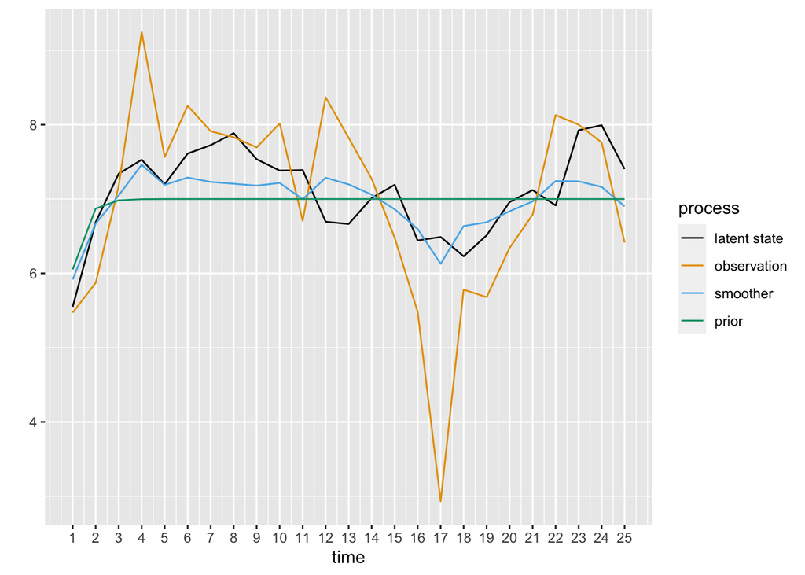

```r
# Kalman smoothing
smoothing <- model$smoothing_moments(theta, observations)

# plot latent and observation process
plot.df <- data.frame(time = times, state = X, process = factor(rep("latent state", nobservations)))
plot.df <- rbind(plot.df, data.frame(time = times, state = Y, process = factor(rep("observation", nobservations))))
plot.df <- rbind(plot.df, data.frame(time = times, state = smoothing$post_mean, process = factor(rep("smoother", nobservations))))
plot.df <- rbind(plot.df, data.frame(time = times, state = smoothing$prior_mean, process = factor(rep("prior", nobservations))))
ggplot(plot.df, aes(x = time, y = state, color = process)) + geom_line() +
  scale_color_colorblind() + ylab("") + scale_x_continuous(breaks = times)
```

# Conditioned particle filters

We first consider a standard particle filter before working with conditional particle filters in which an input trajectory is conditioned to survive all resampling steps. This can be implemented using the `CPF` function of the package without specifying the `ref_trajectory` argument. As input, this function requires some time-discretization objects, number of particles, and an effective sample size threshold to perform adaptive resampling. We plot the effective sample size percentage to inspect the performance of the particle filter.

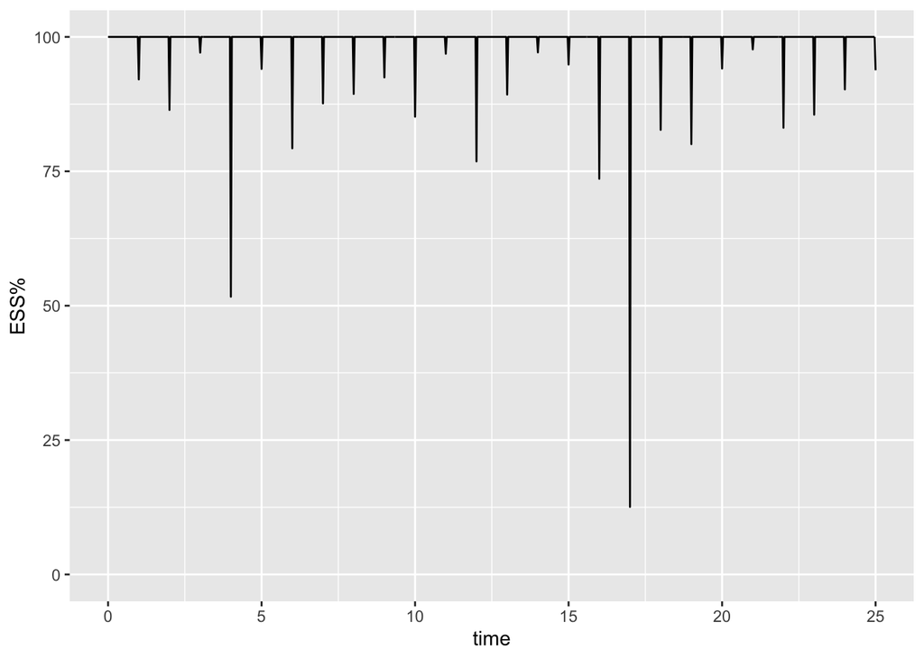

```r
discretization <- model$construct_discretization(level = 5) # construct time-discretization objects
nparticles <- 2^9 # number of particles
resampling_threshold <- 1 # adaptive resampling threshold
pf_output <- CPF(model, theta, discretization, observations, nparticles, resampling_threshold) # run particle filter

# effective sample size plot
state_times <- seq(0, terminal_time, length.out = discretization$statelength)
ess.df <- data.frame(time = state_times, ess = pf_output$ess * 100 / nparticles)
ggplot(ess.df, aes(x = time, y = ess)) + geom_line() +
  labs(x = "time", y = "ESS%") + ylim(c(0, 100))
```

The `new_trajectory` drawn from the particle filter output is an approximate sample from the smoothing distribution (that is increasingly accurate as the number of particles and discretization level go to infinity). To obtain another trajectory whose distribution is closer to the desired smoothing distribution, we can call the function `CPF` to run a conditioned particle filter (CPF) with the initial trajectory as the `ref_trajectory`. We plot these two trajectories below to visualize their behaviour. Note that iteratively running CPF in this manner generates a Markov chain on the space of trajectories that converges to the smoothing distribution at the specified discretization level.

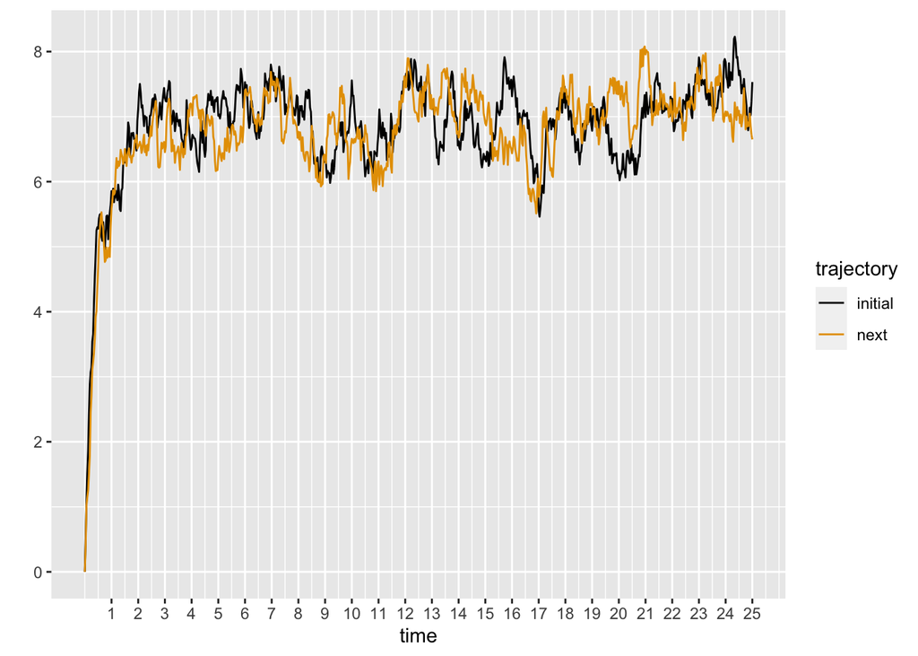

```r
init_trajectory <- pf_output$new_trajectory
cpf_output <- CPF(model, theta, discretization, observations, nparticles, resampling_threshold, ref_trajectory = init_trajectory)
next_trajectory <- cpf_output$new_trajectory
traj.df <- data.frame(time = state_times, state = init_trajectory[1,], trajectory = factor(rep("initial", discretization$statelength)))
traj.df <- rbind(traj.df, data.frame(time = state_times, state = next_trajectory[1,], trajectory = factor(rep("next", discretization$statelength))))
ggplot(traj.df, aes(x = time, y = state, color = trajectory)) + geom_line() +
  scale_color_colorblind() + ylab("") + scale_x_continuous(breaks = times)
```

# Unbiased estimation

Our unbiased estimation methodology removes the *burn-in* bias incurred when one stops at finite number of iterations and also the *time-discretization* bias incurred by fixing the discretization level. Our approach involves a new combination of the multilevel randomization schemes developed by (McLeish 2011), (Rhee and Glynn 2015) and the unbiased Markov chain Monte Carlo methods of (Jacob, Lindsten, and Schön 2019), (Jacob, O’Leary, and Atchadé 2020). Central to our methodology is the development of a new coupling of four CPFs between two successive discretization levels (referred to as coarse and fine levels), with a pair on each level (labelled as chains 1 and 2). This is implemented as the function `coupled4_CPF` in the package, which has the same input arguments as `CPF`, but we have to also specify a function defining a coupled resampling scheme for four CPFs `coupled4_resampling` , and four reference trajectories `ref_trajectory_coarse1`, `ref_trajectory_coarse2`, `ref_trajectory_fine1`, `ref_trajectory_fine2`. Below we demonstrate how to call `coupled4_CPF` by verifying the *faithfulness* property of the pair of chains on the coarse and fine discretization levels, i.e. once the two chains on each discretization level have met, they stay together from then on.

```r
discretization <- model$construct_successive_discretization(level = 5) # construct time-discretization objects on successive levels
coupled4_resampling <- coupled4_maximalchains_maximallevels_independent_residuals # Algorithm 5 of the article

# verify faithfulness of chains on coarse level
ref_trajectory_coarse1 <- CPF(model, theta, discretization$coarse, observations, nparticles, resampling_threshold, ref_trajectory = NULL)$new_trajectory
ref_trajectory_coarse2 <- ref_trajectory_coarse1
ref_trajectory_fine1 <- CPF(model, theta, discretization$fine, observations, nparticles, resampling_threshold, ref_trajectory = NULL)$new_trajectory
ref_trajectory_fine2 <- CPF(model, theta, discretization$fine, observations, nparticles, resampling_threshold, ref_trajectory = NULL)$new_trajectory
output <- coupled4_CPF(model, theta, discretization, observations, nparticles, resampling_threshold, coupled4_resampling,
                            ref_trajectory_coarse1, ref_trajectory_coarse2, ref_trajectory_fine1, ref_trajectory_fine2)
cat("Faithfulness on coarse level:", all(output$new_trajectory_coarse1 == output$new_trajectory_coarse2), "\n")
```

```
## Faithfulness on coarse level: TRUE
```

```r
# faithfulness of chains on fine level
ref_trajectory_coarse1 <- CPF(model, theta, discretization$coarse, observations, nparticles, resampling_threshold, ref_trajectory = NULL)$new_trajectory
ref_trajectory_coarse2 <- CPF(model, theta, discretization$coarse, observations, nparticles, resampling_threshold, ref_trajectory = NULL)$new_trajectory
ref_trajectory_fine1 <- CPF(model, theta, discretization$fine, observations, nparticles, resampling_threshold, ref_trajectory = NULL)$new_trajectory
ref_trajectory_fine2 <- ref_trajectory_fine1
output <- coupled4_CPF(model, theta, discretization, observations, nparticles, resampling_threshold, coupled4_resampling,
                            ref_trajectory_coarse1, ref_trajectory_coarse2, ref_trajectory_fine1, ref_trajectory_fine2)
cat("Faithfulness on fine level:", all(output$new_trajectory_fine1 == output$new_trajectory_fine2), "\n")
```

```
## Faithfulness on fine level: TRUE
```

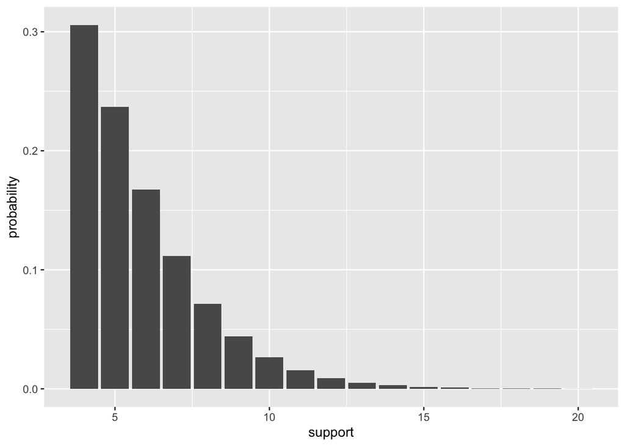

```r
# distribution to truncate discretization level
minimum_level <- 4
maximum_level <- 20
level_distribution <- compute_level_distribution(model, minimum_level, maximum_level)
pmf.df <- data.frame(support = level_distribution$support, probability = level_distribution$mass_function)
ggplot(pmf.df, aes(x = support, y = probability)) + geom_bar(stat="identity")
```

```r
# additional settings
coupled2_resampling <- coupled2_maximal_independent_residuals # Algorithm 3 of the article
initialization <- "dynamics" # choice to initialize CPF chains from time-discretized diffusion process
algorithm <- "CPF" # standard CPF algorithm

# compute independent sum estimator of score function
score <- independent_sum(model, theta, observations, nparticles, resampling_threshold, coupled2_resampling, coupled4_resampling, initialization, algorithm, k = 5, m = 50, level_distribution)
```

```
## running minimum level
## meeting time: 2
## minimum level completed
## random level: 6
## running level 5
## stopping time: 2
## completed
## running level 6
## stopping time: 2
## completed
```

```r
score
```

```
## $random_level
## [1] 6
##
## $unbiasedestimator
## [1] -3.604035  1.815169  1.496885
##
## $cost
## [1] 104448000
##
## $elapsedtime
## elapsed
##   19.73
```

Note that it is important to choose the time-averaging tuning parameters `k` and `m` carefully to control the variance of these unbiased estimators. In this specific example, we can compare our estimate with the exact score function computed using Kalman smoothing.

```r
# compute exact score function with Kalman smoothing
model$compute_gradients(theta, observations)
```

```
## [1] -1.6127602  0.8667747  2.0582012
```

# References

Jacob, Pierre E, Fredrik Lindsten, and Thomas B Schön. 2019. “Smoothing with Couplings of Conditional Particle Filters.” *Journal of the American Statistical Association*.

Jacob, Pierre E, John O’Leary, and Yves F Atchadé. 2020. “Unbiased Markov Chain Monte Carlo Methods with Couplings.” *Journal of the Royal Statistical Society Series B: Statistical Methodology* 82 (3): 543–600.

McLeish, Don. 2011. “A General Method for Debiasing a Monte Carlo Estimator.” *Monte Carlo Methods and Applications* 17 (4): 301–15.

Rhee, Chang-han, and Peter W Glynn. 2015. “Unbiased Estimation with Square Root Convergence for SDE Models.” *Operations Research* 63 (5): 1026–43.